# Generalized Least Squares (GLSs)

2022-09-27

# **The Set-up**

## *Learning objectives.*

1. Implement as Generalized Least Squares model that considers Spatial correlation between observations in `R`.
2. Determine the fit of a Generalized Least Squares model.
3. Reduce a Generalized Least Squares model to the minimum adequate number of predictors using a stepwise procedure.

## *Before you start*

The practical will be run using *RStudio cloud* to avoid individual machine troubleshooting. This means you **need** to have an account for *RStudio cloud*.

However, remember to have [`R`](https://cran.r-project.org) and [R-studio](http://www.rstudio.com/) in your/room computer so you can work on the project after class.

**You should have also** 1. Read chapter 4 of Zuur mixed effect models book. 1. Read chapter 26 of Crawley the R book. 2. Done the Tutorial for this week.

## *The way it’s going to be run*

In this 3h practical you will to implement what you have learned in the class about Regression Analyses in `R`.

You will be building and **R-Markdown** document during the class. **R-Markdown** documents allows you to combine your code, its results, and your prose commentary into a single document. If you manage to produce a document your code works. The resulting file (a html) is what you will hand-in at the end of the practical.

The final document will have three classes of boxes

The text in the blue filled box marked as **Your task** states what you need to do

```r
#
# The code in the window marked like this shows where you need to write your code
#
```

The text in the green filled box marked as **Question** phrases a question, and where you will place the answer to the **question** is marked as ***PLACE YOUR ANSWER HERE**.

## About the data you will use.

The data to be used in this week practical is a combination of the biodiversity data from the [Biowide](https://ecos.au.dk/forskningraadgivning/temasider/biowide) project, which aimed at collecting biodiversity data from 130 terrestrial sampling sites across Denmark. The dataset contains data for Plants (vascular plants and bryophytes), fungi (lichens and macrofungi), gastropods, and arthropods. You can get the [biodiversity data](https://www.gbif.org/dataset/cd4eb3ec-0a18-42b4-bda4-155716ddd7b1#description) from the Danish Biodiversity Information Facility. For further information on the project check the publication.

Although environmental variables were collected as part of Biowide, this data is not available for our use. The data on environmental variables included in the table you will use comes from multiple Geospatial datasets I complied for this course.

Here you will focus on the flowing variables:

**1) decimalLongitude**: East-West position in decimal-degrees of a sample site coming from [Biowide](https://ecos.au.dk/forskningraadgivning/temasider/biowide).

**2) decimalLatitude**: North-South position in decimal-degrees of a sample site coming from [Biowide](https://ecos.au.dk/forskningraadgivning/temasider/biowide).

**3) Log.S.AllGrp**: The total species richness of a sample site (sum of the unique species of all sampled groups in a site) coming from [Biowide](https://ecos.au.dk/forskningraadgivning/temasider/biowide).

**4) AgrBasMp**: Density of agricultural land cover types as defined by [BASEMAP](https://envs.au.dk/en/research-areas/society-environment-and-resources/land-use-and-gis/basemap).

**5) WetLndBasMp**: Density of Wetlands cover types as defined by [BASEMAP](https://envs.au.dk/en/research-areas/society-environment-and-resources/land-use-and-gis/basemap).

**6) Slope30mAgg**: the maximum rate of change in value from that cell to its neighbours estimated based on the [SRTM-30m DEM](https://www2.jpl.nasa.gov/srtm/).

**7) NDVI**: Normalized difference vegetation index, a simple graphical indicator that can be used to analyse vegetation greenness and has strong relation with productivity [Copernicus Global Land Service](https://land.copernicus.eu/global/products/ndvi).

**8) Mean Annual Temperature (MAT)**: Annual average of temperatures coming the [CHELSA-climatologies](https://chelsa-climate.org) ..

**9) Dis2Cost**: Distance in km of a sampled site to the coast estimated by me using Denmark high resolution contour map coming form the Database of Global Administrative Areas [GADAM](https://gadm.org).

**10) HII**: [Human Influence Index](https://sedac.ciesin.columbia.edu/data/set/wildareas-v2-human-influence-index-geographic), a measurement of the anthropogenic impacts on the environment.

**11) PrecSea**: Seasonality of precipitation measured as the variability of monthly values (using the CV) coming the [CHELSA-climatologies](https://chelsa-climate.org).

## 1) The first step: Loading the data

**Your task:**

Load the data in *Biowide_AllSppRichV2.csv*, located in the files of the project

Use `read.csv` to load the file - The file is comma-separated

Save the object as an object named `DK.Biodiv`.

```r
# Read the file and save it as an object named `DK.Biodiv`
DK.Biodiv <-  read.csv("data/Biowide_AllSppRichV2.csv")
# Use the function head to print the five first rows
head(DK.Biodiv)
```

```
##   X ID decimalLongitude decimalLatitude Log.S.AllGrp    AgrBasMp WetLndBasMp
## 1 1  1         10.05716        57.59033    1.0150917 0.002293496 0.015209258
## 2 2  3         10.08032        57.58100    1.0194257 0.098602511 0.000000000
## 3 3  4         10.21615        56.93747    1.0401411 0.270059854 0.039695442
## 4 4  5         10.22988        56.93213    1.0392715 0.000000000 0.175569907
## 5 5  6         10.24092        57.59655    1.0062470 0.000000000 0.000000000
## 6 6  7         10.24669        55.12991    0.9902714 0.004065626 0.002459773
##    Dis2Cost      HII Slope30mAgg      NDVI      MAT  PrecSea
## 1  451.7362 21.19463    2.780004 0.4666667 8.400000 24.00000
## 2 1083.3805 24.66552    2.634712 0.6230000 8.400959 24.08325
## 3 3449.1138 19.21381    1.703675 0.6211111 8.400000 21.00000
## 4 2400.7700 21.06169    2.094643 0.6027778 8.400000 20.93106
## 5 1252.4039 26.72336    2.329034 0.6975294 8.348329 25.00000
## 6 3836.5068 31.90701    5.931717 0.6871111 8.346086 19.26541
```

## 2) Building a regression.

**Your task:**

Use the function `lm()` to build model where all **continuous** predictors, with the exception of `decimalLongitude` and `decimalLatitude` are used to predict `Log.S.AllGrp`.

```r
# Build a glm to predict Log.S.AllGrp based on a linear combination of all NON-positional predictors
DK.Biodiv.lm <- lm(Log.S.AllGrp ~ ., #  the Equations defining the response and additive combination of predictors
                  data = DK.Biodiv[,-c(1:4)]) # dataset (removing the variables not of interest)
# Print the summary of DK.Biodiv.lm
summary(DK.Biodiv.lm)
```

```
##
## Call:
## lm(formula = Log.S.AllGrp ~ ., data = DK.Biodiv[, -c(1:4)])
##
## Residuals:
##       Min        1Q    Median        3Q       Max
## -0.037912 -0.016182 -0.001093  0.010600  0.055237
##
## Coefficients:
##               Estimate Std. Error t value Pr(>|t|)
## (Intercept)  1.053e+00  9.818e-02  10.724  < 2e-16 ***
## AgrBasMp     6.944e-03  1.001e-02   0.694   0.4892
## WetLndBasMp -2.992e-02  2.066e-02  -1.448   0.1506
## Dis2Cost     1.035e-06  2.433e-07   4.254 4.54e-05 ***
## HII          2.476e-04  2.578e-04   0.961   0.3390
## Slope30mAgg -8.393e-04  1.598e-03  -0.525   0.6006
## NDVI        -2.265e-03  2.824e-02  -0.080   0.9362
## MAT         -9.481e-03  1.134e-02  -0.836   0.4051
## PrecSea      1.327e-03  6.402e-04   2.073   0.0406 *
## ---
## Signif. codes:  0 '***' 0.001 '**' 0.01 '*' 0.05 '.' 0.1 ' ' 1
##
## Residual standard error: 0.02179 on 106 degrees of freedom
## Multiple R-squared:  0.2622, Adjusted R-squared:  0.2066
## F-statistic:  4.71 on 8 and 106 DF,  p-value: 5.856e-05
```

## 3) Check your regression.

**Your task:**

- Evaluate graphically the assumptions of your full linear model (`DK.Biodiv.lm`).

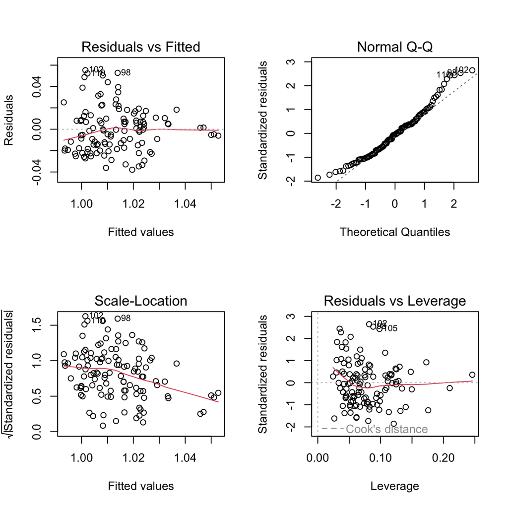

```r
# define a 2x2 plotting space
par(mfrow=c(2,2))
# Evaluate graphically the assumptions of your full linear model
plot(DK.Biodiv.lm)
```

**Question:** Are the following assumptions meet??

**Your task:**

- Evaluate if the predictors in `DK.Biodiv.lm` are collinear.

```r
# Evaluate if the predictors in `DK.Biodiv.lm` are collinear.
1 / car::vif(DK.Biodiv.lm)
```

```
##    AgrBasMp WetLndBasMp    Dis2Cost         HII Slope30mAgg        NDVI
##   0.8386838   0.9034365   0.6952669   0.8604189   0.5019589   0.7578862
##         MAT     PrecSea
##   0.4314071   0.6660668
```

**Question:** Are predictors collinear?.

No, all tolerances are above 0.1 (vif are below 10)

**Your task:**

- Evaluate graphically the assumptions of independence of observations. (`DK.Biodiv.lm`).

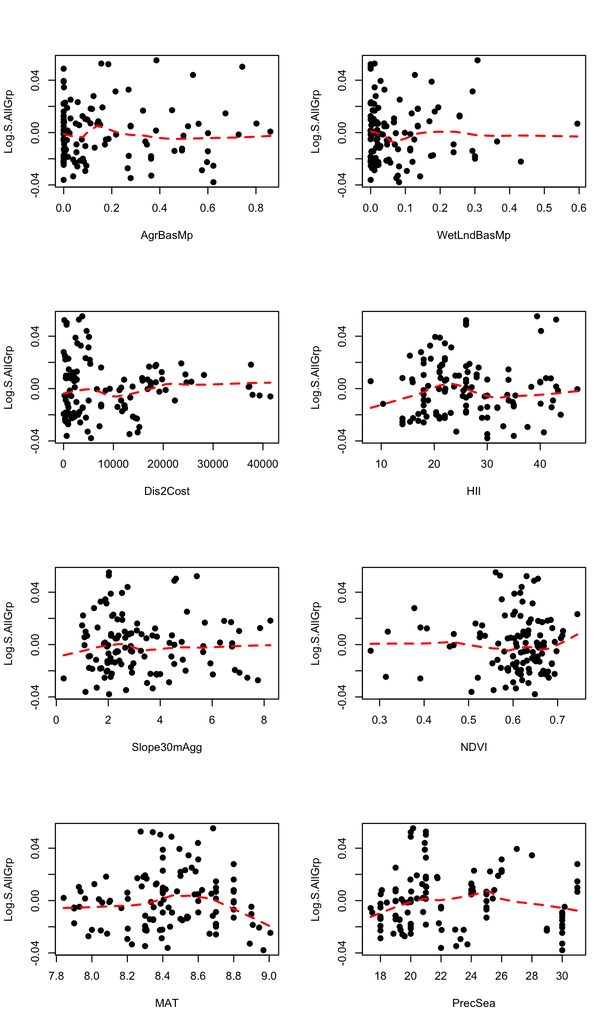

```r
# Set a piloting space

par(mfrow=c(round(length(names(coef(DK.Biodiv.lm))[-1])/2),2))
# Loop across the predictors
for(VarUse in names(coef(DK.Biodiv.lm))[-1]){
# Plot the Residuals vs the predictor
  plot(y = residuals(DK.Biodiv.lm), # Residuals
       x = DK.Biodiv[,VarUse], # Predictor
       ylab = "Log.S.AllGrp", # Labels
       xlab = VarUse, # Labels
       pch=19)  # Point type
# add a smoother trend line using lowess
    lines(lowess(y = residuals(DK.Biodiv.lm), # Residuals
               x = DK.Biodiv[,VarUse]),# Predictor
        lwd = 2, # Line width
        lty = 2, # Dashed line
        col = "red")  # colour of the line
}
```

**Question:** Is there independence of observations?.

Based on the figure I would say Yes! as there is no strong-trends in the relation between the residuals and either of the predictors.

## 4) Detecting spatial autocorrelation

**Your task:**

- Create a Spatial object with the data in `DK.Biodiv`. For this, you will:
  1. Copy the data in `DK.Biodiv` into an object names `DK.Biodiv.Spatial`.
  2. Extract the standardized residuals of the `DK.Biodiv.lm` object using the function `rstandard()`; and add these to `DK.Biodiv.Spatial.` as a variable named `Resid`.
  3. Transform the `DK.Biodiv.Spatial` object from a `data.frame` to a `SpatialPointsDataframe` using the function `coordinates()`.
  4. Define the right reference system to `DK.Biodiv.Spatial` using the function `proj4string()`..
  5. Re-project `DK.Biodiv.Spatial` to `UTM/ETRS89` using the function `spTransform()`.

```r
# Copy the data in `DK.Biodiv` into an object names `DK.Biodiv.Spatial`.
DK.Biodiv.Spatial <- DK.Biodiv # copy the original data

# Extract the standardized residuals of the `DK.Biodiv.lm` object
DK.Biodiv.Spatial$Resid <- rstandard(model = DK.Biodiv.lm) # Model to extract the residuals

# Transform the `DK.Biodiv.Spatial` to a `SpatialPointsDataframe`
coordinates(DK.Biodiv.Spatial) <- ~decimalLongitude+decimalLatitude

# Define the right reference system to `DK.Biodiv.Spatial`.
proj4string(DK.Biodiv.Spatial) <- CRS("+proj=longlat") # The

# Re-project `DK.Biodiv.Spatial` to `UTM/ETRS89`.
DK.Biodiv.Spatial <- spTransform(DK.Biodiv.Spatial, # object to be transformed
                                 CRSobj = CRS("+proj=utm +zone=32 +ellps=intl +towgs84=-87,-98,-121,0,0,0,0 +units=m +no_defs +type=crs")# New Projection
)
```

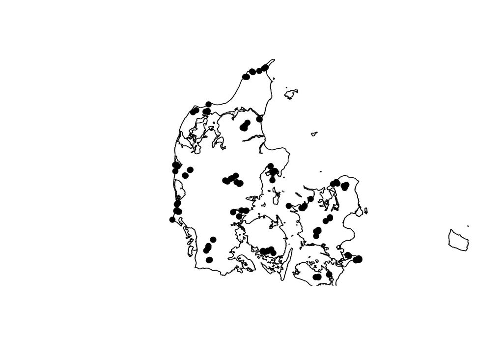

```r
# Add the projected X and Y to the Data frame of the Spatial object
DK.Biodiv.Spatial$X <- coordinates(DK.Biodiv.Spatial)[,'decimalLongitude']
DK.Biodiv.Spatial$Y <- coordinates(DK.Biodiv.Spatial)[,'decimalLatitude']

# Plot the spatial object you created
plot(DK.Biodiv.Spatial,
     pch=19)
# Load a map of Denmark
DK.Map <- readRDS("data/gadm36_DNK_0_sp.rds")
# Re-project `DK.Map` to `UTM/ETRS89`.
DK.Map <- spTransform(DK.Map, # object to be transformed
                      CRSobj = CRS("+proj=utm +zone=32 +ellps=intl +towgs84=-87,-98,-121,0,0,0,0 +units=m +no_defs +type=crs") # New Projection
                      )
# plot DK.Map over DK.Biodiv.Spatial
plot(DK.Map,add=T)
```

**Your task:**

- Generate a map to represent the spatial variation in the residual variation from the `DK.Biodiv.lm` model. For this, you will:
  1. Add to `DK.Biodiv.Spatial` the normalized residuals from the `DK.Biodiv.lm` model as a variable names `Resid`. You will get these using the function `rstandard()`.
  2. Use the function `bubble()` from the package `sp`to generate this spatial representation of the normalized residual variation.

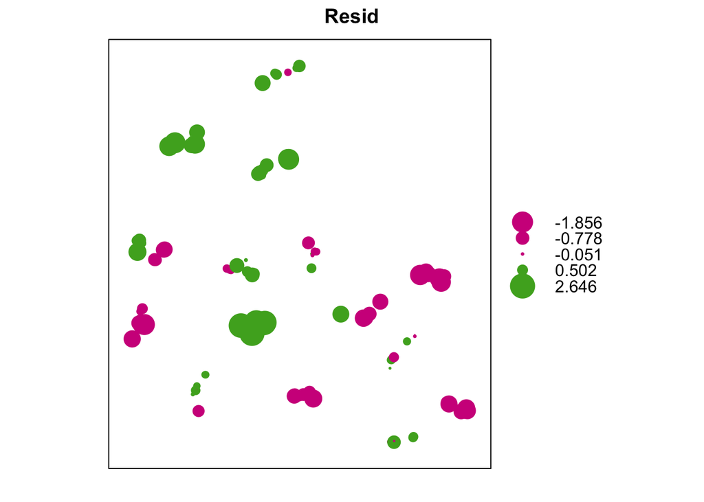

```r
# Add to `DK.Biodiv.Spatial` the normalized residuals to the Spatial object
DK.Biodiv.Spatial$Resid <- rstandard(DK.Biodiv.lm)
#spatial representation of the normalized residual variation.
bubble(obj = DK.Biodiv.Spatial, # the Spatial object to plot
      zcol = "Resid")# column name, or column number of the variable to plot
```

**Question:** there is a clear spatial pattern in the residuals?.

Yes, there is a clear spatial pattern in the residuals. Observations with similar residuals come from sampling units that were closer together in space and thus there is evidence of spatial autocorrelation.

## 5) Building a semi-variogram to quantify the Autocorrelation.

**Your task:**

- Re-run your best model using a Generalised least Squares method. For this, you will use the function `gls()` and the data in `DK.Biodiv.Spatial`.
- Save the the model as an object named `DK.Biodiv.gls`.

```r
# Make the reduced model a Generalised least Squares model
DK.Biodiv.gls <- gls(formula(DK.Biodiv.lm), # Get the Formula form the LM model
                     data = DK.Biodiv.Spatial, # The data.frame,e with the variables
                     method ="REML" # The inference method
                     )

# call the summary of DK.Biodiv.gls
summary(DK.Biodiv.gls)
```

```
## Generalized least squares fit by REML
##   Model: formula(DK.Biodiv.lm)
##   Data: DK.Biodiv.Spatial
##         AIC       BIC   logLik
##   -437.9339 -411.2995 228.9669
##
## Coefficients:
##                  Value  Std.Error   t-value p-value
## (Intercept)  1.0529109 0.09818255 10.724012  0.0000
## AgrBasMp     0.0069443 0.01000651  0.693978  0.4892
## WetLndBasMp -0.0299151 0.02066224 -1.447816  0.1506
## Dis2Cost     0.0000010 0.00000024  4.254243  0.0000
## HII          0.0002476 0.00025781  0.960578  0.3390
## Slope30mAgg -0.0008393 0.00159822 -0.525135  0.6006
## NDVI        -0.0022651 0.02824366 -0.080198  0.9362
## MAT         -0.0094809 0.01134314 -0.835825  0.4051
## PrecSea      0.0013273 0.00064022  2.073273  0.0406
##
##  Correlation:
##             (Intr) AgrBsM WtLnBM Ds2Cst HII    Slp30A NDVI   MAT
## AgrBasMp     0.156
## WetLndBasMp  0.092  0.027
## Dis2Cost    -0.358 -0.031 -0.151
## HII         -0.010 -0.215 -0.013 -0.214
## Slope30mAgg -0.479  0.063  0.162  0.074  0.075
## NDVI        -0.238  0.004  0.007 -0.200 -0.016 -0.224
## MAT         -0.966 -0.202 -0.131  0.424 -0.078  0.429  0.072
## PrecSea      0.094  0.231  0.096 -0.200  0.167  0.250  0.081 -0.287
##
## Standardized residuals:
##         Min          Q1         Med          Q3         Max
## -1.74026460 -0.74280850 -0.05015677  0.48654401  2.53553211
##
## Residual standard error: 0.0217853
## Degrees of freedom: 115 total; 106 residual
```

**Question:**

1. Is there any change in the regression coefficients when ruing the model with the function `gls()`?.

NO!. The model coefficients are the same.

2. Why you do not get a R<sup>2</sup> or Adjusted-R<sup>2</sup> when ruining the model with the function `gls()`?

Because the model is done using Restricted Maximum Likelihood, and R<sup>2</sup> are only defined for OLS estimation.

**Your task:**

- Generate a variogram for the residuals from `DK.Biodiv.gls`. For this, you will use the function `Variogram()` from the `nlme` package. See the help file from the function `Variogram()` to see how to use this.

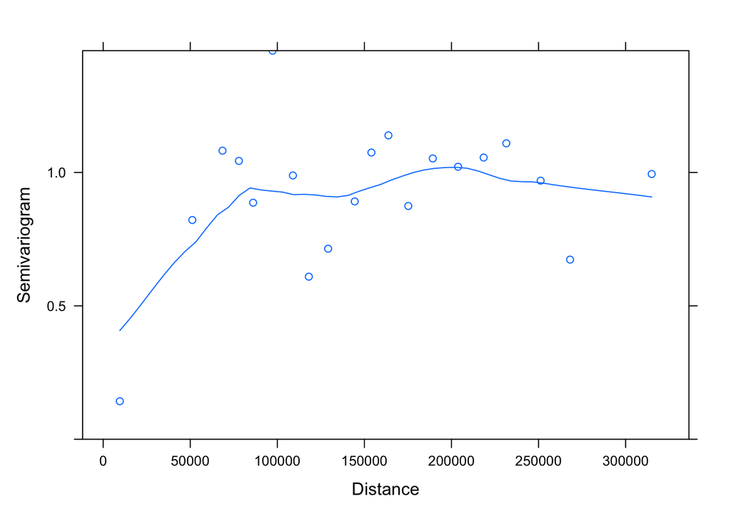

```r
# Generate a semi-variogram for the residuals from `DK.Biodiv.gls`.

DK.Biodiv.gls.Vargrm <- Variogram(DK.Biodiv.gls, # The gls model
                                  form = ~ X + Y, # the way correlation is defined - here as
                                  resType = "normalized" # the type of residuals to use
                                  )
# Plot the semi-variogram
plot(DK.Biodiv.gls.Vargrm)
```

**Question:** Is there autocorrelation in the residuals?.

Based on the semivariogram, I would say that there is correlation in the residuals - there is consistent- asymptotic trend.

## 6) Moran-I: An Statistic for Autocorrelation.

**Your task:**

- Estimate the Moran’s I statistic (which is a measure of spatial autocorrelation) using the function `Moran.I()` of the package `ape`. For this, you will:
  1. Create a distance matrix between all the observations using the function `dist()`, and the projected coordinates. Save the distance matrix as an object named `DistDKBio`.
  2. Extract the `normalized` residuals of the gls model (`DK.Biodiv.gls`). Save these as a object names `NorResGLS`.
  3. Estimate Moran I of the residuals using the function `Moran.I()` of the package `ape`.

```r
# Create a distance matrix using the coordinates
DistDKBio <- dist(coordinates(DK.Biodiv.Spatial))

#Extract the `normalized` residuals
NorResGLS <- residuals(DK.Biodiv.gls, # Model
                       type = "normalized"# the residuals type
                       )

# Estimate Moran I of the residuals
Moran.I(NorResGLS, # the variable to evaluate
        w = as.matrix(DistDKBio) # the Distance matrix
        )
```

```
## $observed
## [1] -0.08022341
##
## $expected
## [1] -0.00877193
##
## $sd
## [1] 0.005289692
##
## $p.value
## [1] 1.408873e-41
```

**Question:** Is there autocorrelation in the residuals based on Moran I? - Check the help file of the function `Moran.I()` to see wit is tested.

Moran I null hypothesis is that there is no Autocorrelation. So based on this the model suggest that there IS Spatial correlation as the test rejects this null-hypothesis.

## 7) Accommodating spatial autocorrelation in the model.

**Your task:**

- Refit the model `DK.Biodiv.gls` using the flowing correlation structures:
  1. Exponential.
  2. Gaussian
  3. Spherical
  4. Rational quadratic

Remember to use the projected spatial object, and use the projected Coordinates when defining the correlation structures.

```r
# Fit an Exponential correlation model
DK.Biodiv.glsExp <- gls(formula(DK.Biodiv.gls), # Formula of the model
                        data = DK.Biodiv.Spatial, # Source data location
                        correlation = corExp(form = ~X + Y, # Formula to define the correlation based on distances
                                               nugget = TRUE), # is there variation when the distace is Zero
                         method = "REML" # Estimation method
                         )

# Fit a Gaussian correlation model
DK.Biodiv.glsGaus <- gls(formula(DK.Biodiv.gls), # Formula of the model
                         data = DK.Biodiv.Spatial, # Source data location
                         correlation = corGaus(form = ~X + Y, # Formula to define the correlation based on distances
                                               nugget = TRUE), # is there variation when the distace is Zero
                         method = "REML" # Estimation method
                         )

# Fit a Rational quadratic correlation model
DK.Biodiv.glsRatio <- gls(formula(DK.Biodiv.gls), # Formula of the model
                          data = DK.Biodiv.Spatial, # Source data location
                          correlation = corRatio(form = ~X + Y, # Formula to define the correlation based on distances
                                               nugget = TRUE), # is there variation when the distace is Zero
                         method = "REML" # Estimation method
                         )

# Fit an Spherical correlation model
DK.Biodiv.glsSpher <- gls(formula(DK.Biodiv.gls), # Formula of the model
                          data = DK.Biodiv.Spatial,
                          correlation = corSpher(form = ~X + Y, # Formula to define the correlation based on distances
                                               nugget = TRUE), # is there variation when the distace is Zero
                         method = "REML" # Estimation method
                         )
```

**Your task:** * Contrast the AIC of the different models

```r
#Contrast the AIC of the different models
AIC(DK.Biodiv.glsExp, # Exponential model
    DK.Biodiv.glsGaus, # Gaussian model
    DK.Biodiv.glsRatio, # Ratio model
    DK.Biodiv.glsSpher # Sperical model
    )
```

```
##                    df       AIC
## DK.Biodiv.glsExp   12 -674.1381
## DK.Biodiv.glsGaus  12 -667.2166
## DK.Biodiv.glsRatio 12 -673.4402
## DK.Biodiv.glsSpher 12 -677.3559
```

**Question:** Based on the AIC which is the best model?.

The model with a Spherical correlation structure is the best model.

**Your task:** Contrast the the best model with a correlation structure to that of the model with out one (`DK.Biodiv.gls`). For this, you will use the function `anova()`.

```r
#Contrast the  the best model with a correlation structure to that of the model with out one
anova(DK.Biodiv.glsSpher, # Model with spatial correlation structure
      DK.Biodiv.gls # Model with OUT spatial correlation structure
      )
```

```
##                    Model df       AIC       BIC   logLik   Test L.Ratio p-value
## DK.Biodiv.glsSpher     1 12 -677.3559 -645.3946 350.6779
## DK.Biodiv.gls          2 10 -437.9339 -411.2995 228.9669 1 vs 2 243.422  <.0001
```

**Question:** Best on the AIS which is the best model .

Based on the Log-likelihood ratio test the model with a Spatial-Correlation structure is the best model - It is significant different that a model without the structure and has lower AIC.

## 8) Select the best Fixed effects.

**Your task:**

- Now that you have defined the best correlation structure; select the best set of predictors. For this, you will:
  1. Redefine the model with a correlation structure, by updating the inferencer method. Use the function `update()` for this.
  2. Use the function `setpAIC()` from the package `MASS` to do the model section using a `both` directions stepwise search.
  3. Redefine the model with a correlation structure, by updating the inferencer method. Use the function `update()` for this.

```r
# updating the inferencer method of the model with a correlation structure
DK.Biodiv.glsSpher.ML <- update(DK.Biodiv.glsSpher, # Original model
                                method="ML" # Update the inference method
                                )
# Use a
DK.Biodiv.glsSpher.ML.Updated <- MASS::stepAIC(DK.Biodiv.glsSpher.ML, # regression object
                                               direction = "both", # Stepwise direction
                                               trace = 0) # No print out

# Call the summary of the reduced model
summary(DK.Biodiv.glsSpher.ML.Updated)
```

```
## Generalized least squares fit by maximum likelihood
##   Model: Log.S.AllGrp ~ Dis2Cost + HII
##   Data: DK.Biodiv.Spatial
##         AIC       BIC   logLik
##   -800.9623 -784.4927 406.4811
##
## Correlation Structure: Spherical spatial correlation
##  Formula: ~X + Y
##  Parameter estimate(s):
##        range       nugget
## 9.433652e+04 1.003624e-03
##
## Coefficients:
##                  Value   Std.Error   t-value p-value
## (Intercept)  1.0155773 0.006068622 167.34890  0.0000
## Dis2Cost     0.0000005 0.000000281   1.63285  0.1053
## HII         -0.0001599 0.000078978  -2.02504  0.0452
##
##  Correlation:
##          (Intr) Ds2Cst
## Dis2Cost -0.275
## HII      -0.289 -0.153
##
## Standardized residuals:
##         Min          Q1         Med          Q3         Max
## -2.00206348 -0.95929191 -0.09731684  0.82677209  2.75486081
##
## Residual standard error: 0.02052711
## Degrees of freedom: 115 total; 112 residual
```

```r
# updating the inferencer method of the model with a correlation structure
DK.Biodiv.glsSpher.ML.Updated <- update(DK.Biodiv.glsSpher.ML.Updated, #Original model
                                        method="REML"# Update the inference method
                                        )

# Call the summary of the reduced model after updating the inference method.
summary(DK.Biodiv.glsSpher.ML.Updated)
```

```
## Generalized least squares fit by REML
##   Model: Log.S.AllGrp ~ Dis2Cost + HII
##   Data: DK.Biodiv.Spatial
##         AIC       BIC   logLik
##   -746.3679 -730.0569 379.1839
##
## Correlation Structure: Spherical spatial correlation
##  Formula: ~X + Y
##  Parameter estimate(s):
##        range       nugget
## 1.180614e+05 7.931566e-04
##
## Coefficients:
##                  Value   Std.Error   t-value p-value
## (Intercept)  1.0146108 0.007407942 136.96257  0.0000
## Dis2Cost     0.0000004 0.000000283   1.49409  0.1380
## HII         -0.0001618 0.000078135  -2.07085  0.0407
##
##  Correlation:
##          (Intr) Ds2Cst
## Dis2Cost -0.202
## HII      -0.229 -0.139
##
## Standardized residuals:
##         Min          Q1         Med          Q3         Max
## -1.73097824 -0.80214538 -0.04059339  0.81980775  2.49177271
##
## Residual standard error: 0.0231582
## Degrees of freedom: 115 total; 112 residual
```

## 9) Last check

**Your task:**

- Evaluate graphically the assumptions of your reduced linear model. Here only focus on:
  1. Homogeneity of variances.
  2. Normality of the residuals

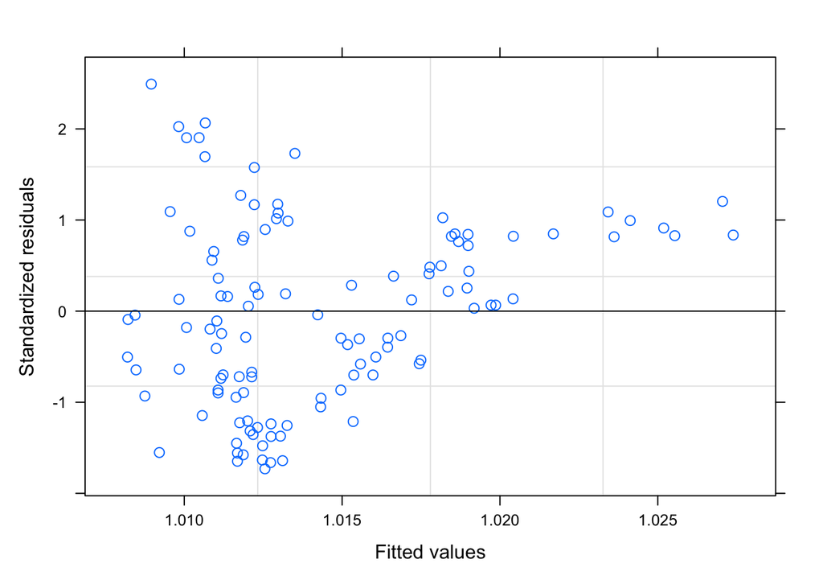

```r
# Evaluate graphically the assumptions of your reduced linear model
plot(DK.Biodiv.glsSpher.ML.Updated, # Model
     abline=0, # add a horizontal line at Zero
     idResType = "normalized" # Residual type
     )
```

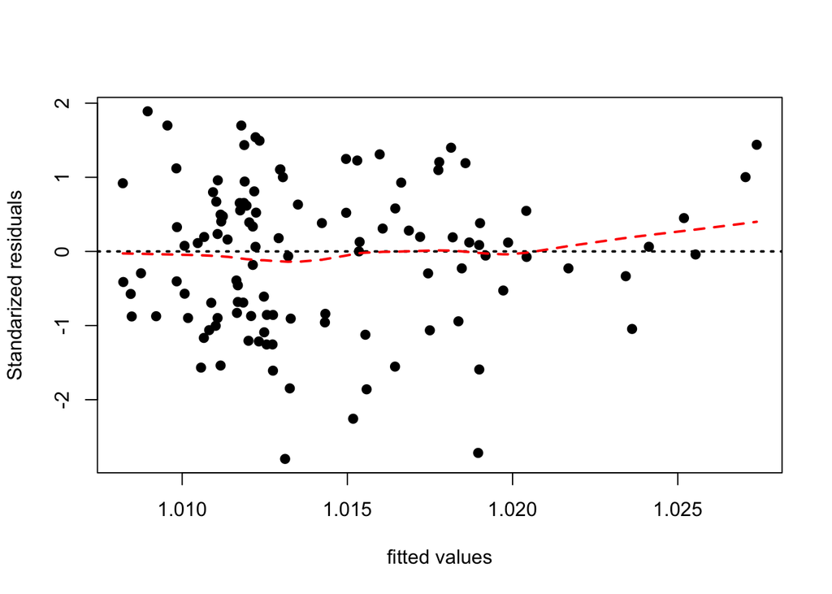

```r
# OR
plot(y = residuals(DK.Biodiv.glsSpher.ML.Updated,"normalized"), # Residuals
     x = predict(DK.Biodiv.glsSpher.ML.Updated),# Predictor
     pch=19, #point type
     ylab = "Standarized residuals", # y-axis Label
     xlab = "fitted values" # x-axis Label
     )
# Horizontal line
abline(h=0,
       lty=3,
       lwd=2)
# Trend line
lines(lowess(y = residuals(DK.Biodiv.glsSpher.ML.Updated,"normalized"), # Residuals
               x = predict(DK.Biodiv.glsSpher.ML.Updated)),# Predictor
        lwd = 2, # Line width
        lty = 2, # Dashed line
        col = "red")  # colour of the line
```

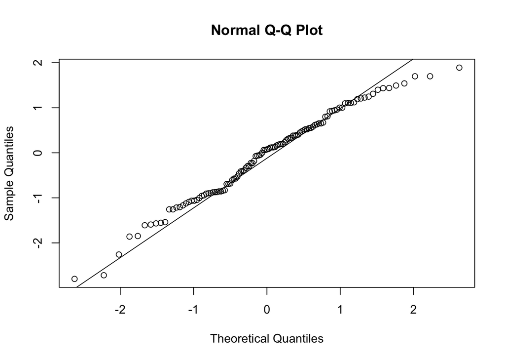

```r
# Evaluate graphically the assumptions of your reduced linear model
qqnorm(residuals(DK.Biodiv.glsSpher.ML.Updated,type="normalized"))
qqline(residuals(DK.Biodiv.glsSpher.ML.Updated,type="normalized"))
```

**Question:** Are the following assumptions meet??

1. Homogeneity of variances? At first glance it appears that the standardized residuals are homogeneous; But the Standardized residuals vs. fitted values shows a triangular shape which indicates lack of homogeneity of variances.
2. Normality of residuals? The qq-plot would appear to show that the standardized residuals are normal.

**Your task:**

- Generate a variogram for the residuals from the final reduced model. For this, you will use the function `Variogram()` from the `nlme` package.

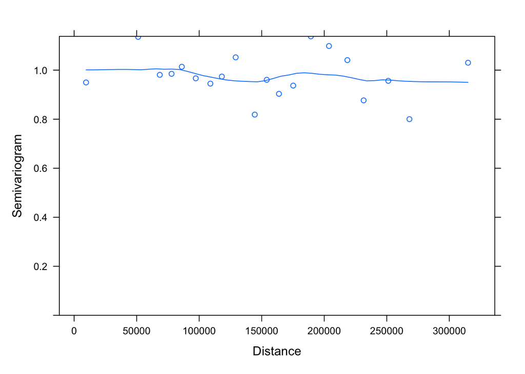

```r
# Generate a semi-variogram for the residuals from the reduced model.

DK.Biodiv.gls.Vargrm2 <- Variogram(DK.Biodiv.glsSpher.ML.Updated, # Model
                                   form = ~ X + Y, # Formula of how to define the distance
                                   resType = "normalized" # Residual type
                                   )
# Plot the semi-variogram
plot(DK.Biodiv.gls.Vargrm2)
```

**Question:** Is there autocorrelation in the residuals?.

Based on the semivariogram, I would say that there is NOT correlation in the residuals - the variogram is flat.